# Content Analysis of Raymond Moley’s Reporting from 1942 - 1964

## Economic vs Political Articles Over Time

I generated the lists to determine economic and political articles using ChatGPT, giving it the following prompts.

### For economic words:

“Give me a list of words in the english language that have an economic connotation.” “Add the words economy, economic, money, and union”

Sample of Economic Terms

| Word |
| --- |
| Investment |
| Capital |
| Profit |
| Revenue |
| Loss |
| Market |
| Equity |
| Assets |
| Liabilities |
| Income |
| Expense |
| Inflation |
| Deflation |
| Supply |
| Demand |
| Growth |
| Recession |
| Depression |
| Commerce |
| Trade |

### For political words:

“Give me a list of words in the English language that have a political connotation specific to the years 1932-1960 but also general political terms. Specific to american politics.”

Sample of Political Terms

| Word |
| --- |
| Government |
| government |
| Legislation |
| legislation |
| Democracy |
| democracy |
| Republic |
| republic |
| Policy |
| policy |
| Election |
| election |
| Constitution |
| constitution |
| Amendment |
| amendment |
| Congress |
| congress |
| Senate |
| senate |

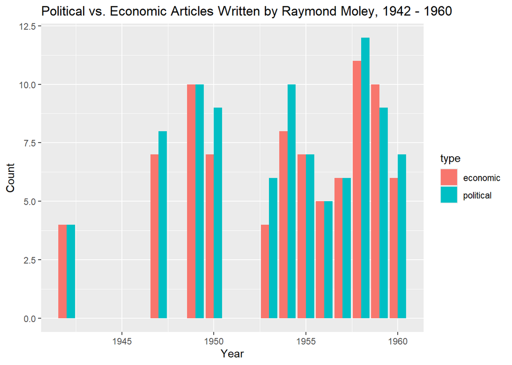

## Sentiment Analysis of Coverage of Presidential Candidates

### Dewey

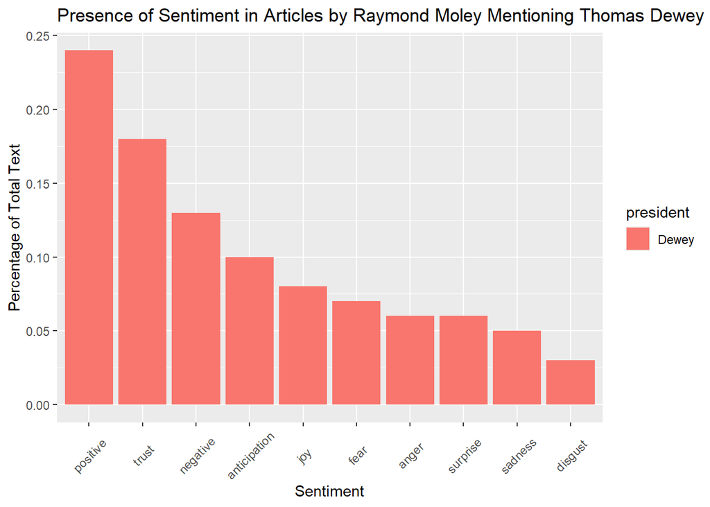

### Nixon

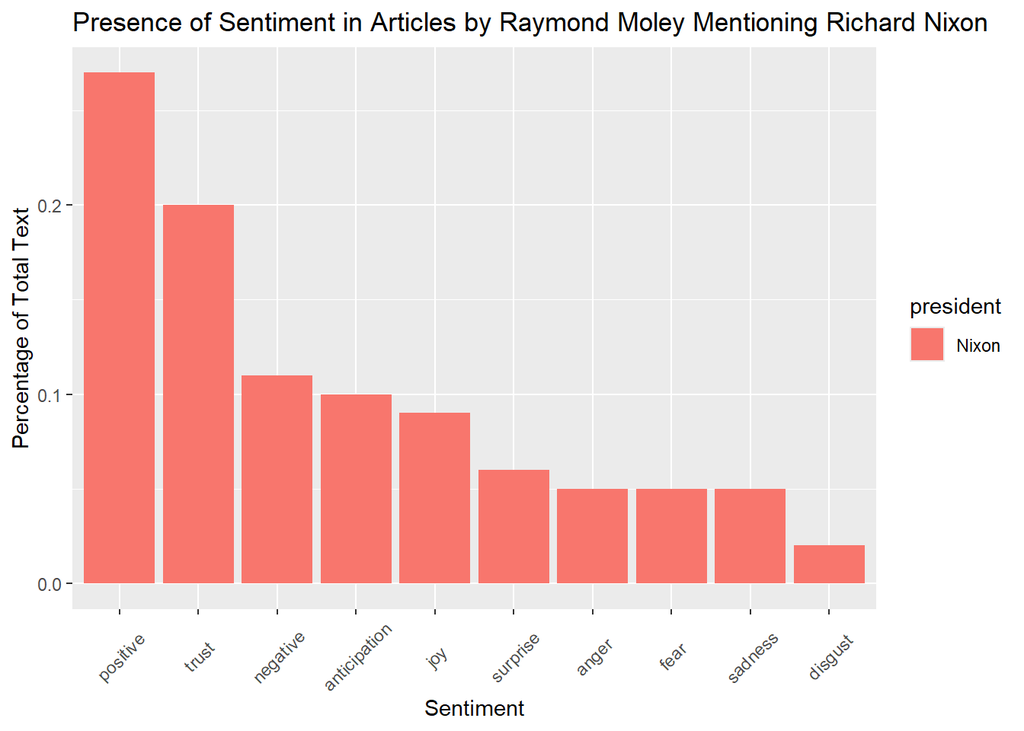

### Comaprison

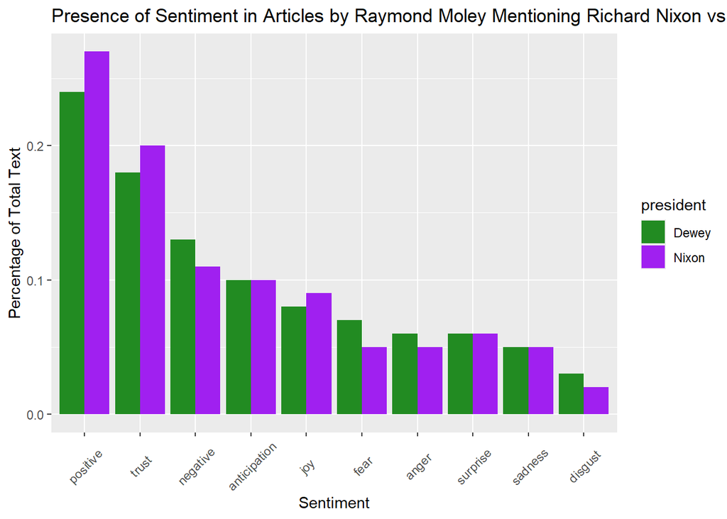

## Overall Sentiment Analysis

### All Articles

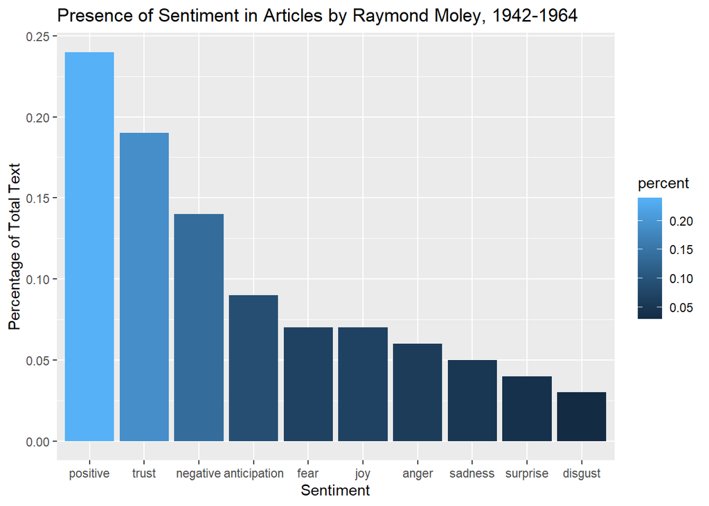

### By Decade

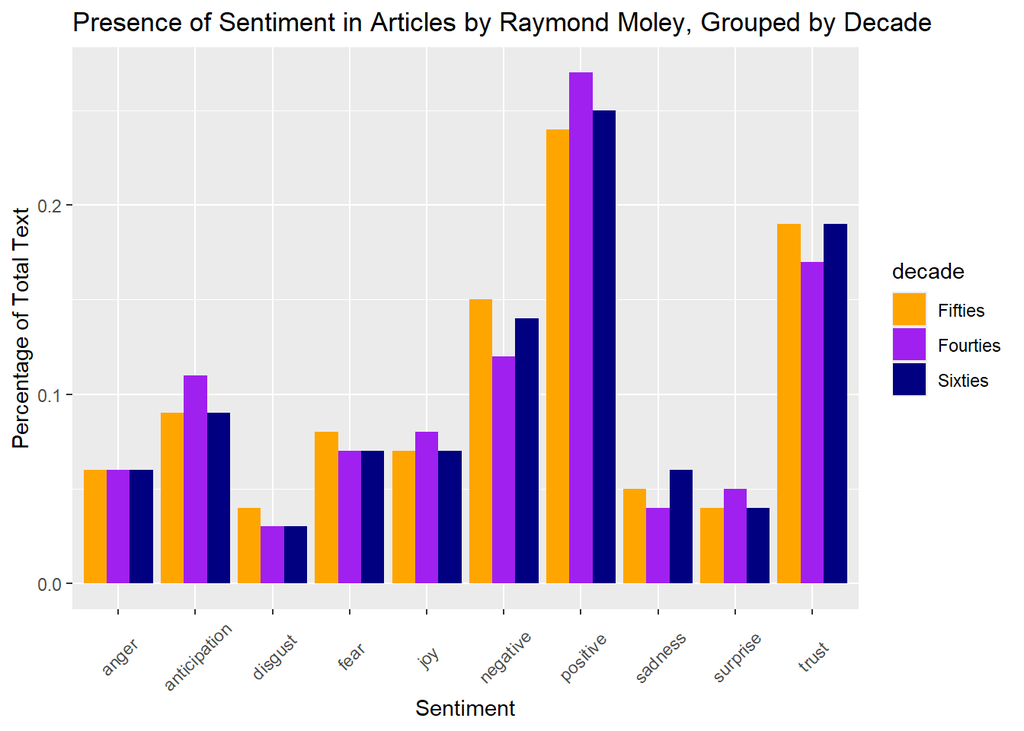

## Topic Model

For some reason the graph below is turning gray. I get the message “Scale for fill is already present. Adding another scale for fill, which will replace the existing scale.” when I try to load it, and also trying to load the graph in the topic model sample exercise. I am not sure what to do, looking online did not help. I am uploading a screenshot of the graph here: https://github.com/blangumd/CompText_Jour_FinalProject/blob/main/topic_model_vis.png

[figure not shown]

## Sample Codes

**federal government** - Anything descriptive about the federal government in terms of entity or location

**economic policy** - Describing or critiquing policy, habits, or status of the economy and any specific person’s interactions or influence on it.

**commentary** - Any statements of clear opinion, not based or citing of facts.

**election** - Relating to or commenting on an ongoing, past, or future election, its candidates, its status, and/or expected or hoped-for outcome.

## Essay

The data itself is currently a collection of 105 articles, written by Raymond Moley for Newsweek between the years 1942 and 1960. For each article there is a known filename, length, and date of publication, along with the contents of each article. There were a few iterations of importing data before a final process and dataset was established. The issue mainly lied in the way that the articles needed to be scanned, as the format was columns, which are difficult for a usual PDF scanning software to decipher. Dr. Wells used a variety of methods, including artififical intelligence, to gather these articles and put them into a final set of 105 articles with an accompanying index. All but one of the articles written in 1948 were corrupted, showing up as lines of “[?]” rather than text. The cause of this issue is unknown, but it is interesting that it was all articles from 1948. I excluded the one functional article from 1948 in order to prevent the data being skewed in any analysis done based on year or decade.

Both figures had the same four most common sentiments, which are “positive”, “trust”, “negative”, and then “anticipation”. However, in comparing the sentiment analyses of coverage on Nixon vs. coverage on Dewey, there is a clear difference in the attitude and tone that Moley used for each president. For example, in an article Moley wrote in 1950, he states that “Richard Nixon, a young, aggressive, and attractive conservative, will get the Republican nomination almost unopposed.” This statement is a clear statement of not only support for Nixon but anticipation that he is going to win the nomination. In contrast, he wrote about Dewey that “disaster befell Thomas E. Dewey in 1948 because his great confidence in polls shaped his carefree,”it’s-in-the-bag” campaign. But at the moment nothing so occupies the attention of several putative Presidential candidates as polls.” He describes Dewey’s attitudes about the election in a almost mocking manner, impLying that his confidence is unfounded and not helpful.

The final form of analysis I conducted was a topic model, with k=6 categories generated. It is important to note that there was a category generated of meta data such as the names of articles and the publication that would have been very tedious to remove via code. Thus, there are only five categories that really say much about the themes and narratives of Moley’s reporting. The topic that I found the most intriguing was the one I labeled “american_ideals”, which included words like “men” and “economy”.